# 2026-03-02-normal-distribution

## Normal (Gaussian) Distribution

The normal distribution, also known as the Gaussian distribution, is the most common form of distribution of a random variable, characterized by its bell-shaped curve. It describes many natural phenomena and serves as a foundation in probability theory and statistics. In statistics it forms the basis for the Central Limit Theorem.

A normal distribution is defined by two parameters: the mean $\mu$, defining its center, and the variance $\sigma^2$, defining its spread.

**Notation**: $X\sim\mathcal{N}(\mu,\sigma^2)$

### Probability Density Function

A probability density function (PDF) describes a probability distribution of a continuous, random variable. Plotting the PDF of a normal distribution provides a symmetric, bell-shaped curve.

**Formula**: $f(x, \mu, \sigma)=\frac{1}{\sigma\sqrt{2\pi}}e^\frac{-(x-\mu)^2}{2\sigma^2}$

Where:

- x is a random variable
- $\mu$ is the distribution mean
- $\sigma$ is the distribution standard deviation
- e is the base of the natural logarithm; Euler's number; (approx. 2.71828)
- $\pi$ is the mathematical constant pi (approx. 3.14159)

### Plotting Normal Distributions

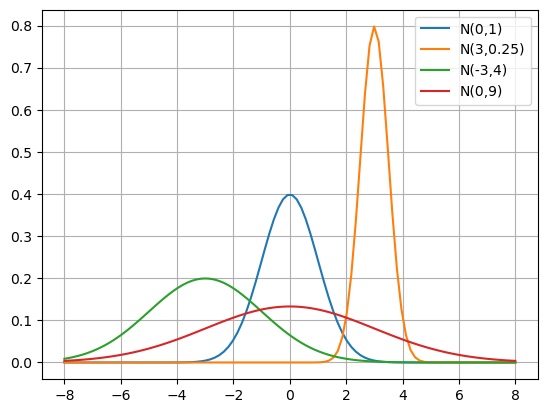

```python
from scipy.stats import norm
import numpy as np
import matplotlib.pyplot as plt

x = np.linspace(-8, 8, 100)

def plot_dist(mean, std):
    y = norm.pdf(x, loc=mean, scale=std)
    plt.plot(x, y, label=f"N({mean},{std**2})")

plot_dist(0, 1)
plot_dist(3, 0.5)
plot_dist(-3, 2)
plot_dist(0, 3)
plt.grid()
plt.legend()
```

A distribution is normal if the following two conditions apply:

- Symmetry:

  A normal distribution is completely symmetric around the mean. Thus it is zero-skewed and mean median and mode are all equal.
- Empirical Rule:

  The empirical rule states that in a normal distribution about 68% of the data falls within 1 standard deviation of the mean, about 95% within 2 standard deviations, and about 99.7% within 3 standard deviations.

### Visualize the Empirical Rule

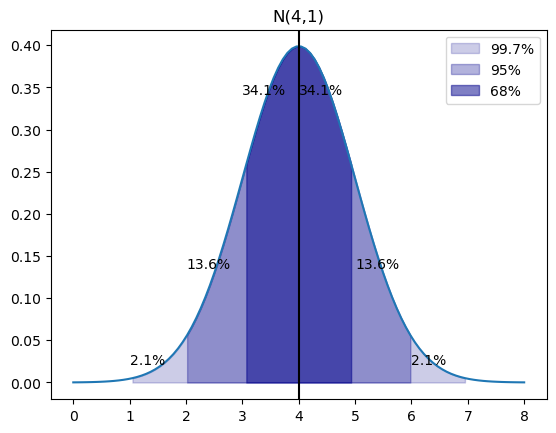

```python
import numpy as np
from scipy.stats import norm
import matplotlib.pyplot as plt
import pandas as pd
from scipy.integrate import quad

mean = 4
std = 1
x = np.linspace(0, 8, 100)
y = norm.pdf(x, loc=mean, scale=std)
df = pd.DataFrame([(i, j) for i, j in zip(x, y)], columns=["x", "y"])

def split_density(n_std):
    x_ = df.x[(df.x >= mean-std*n_std) & (df.x <= mean+std*n_std)]
    return (x_, df.y.loc[x_.index[0] : x_.index[-1]])

plt.plot(x, y)
plt.axvline(mean, c="black")
std_1 = split_density(1)
std_2 = split_density(2)
std_3 = split_density(3)
plt.fill_between(std_3[0], std_3[1], color="darkblue", alpha=0.2, label="99.7%")
plt.fill_between(std_2[0], std_2[1], color="darkblue", alpha=0.3, label="95%")
plt.fill_between(std_1[0], std_1[1], color="darkblue", alpha=0.5, label="68%")
plt.title(f"N({mean},{std**2})")
plt.legend()

for i in range(1, 7):
    value, _ = quad(norm.pdf, i, i+1, args=(loc:=mean, scale:=std))
    perc = f"{np.round(value * 100, 1)}%"
    plt.text(i, value, perc)
```

### Standard Normal Distribution

The standard normal distribution is a normal distribution where the mean equals 0 and the standard deviation equals 1, $Z\sim\mathcal{N}(0,1)$. Any normal distribution can be converted to the standard normal distribution by subtracting the mean and then dividing by the standard deviation, $Z=\frac{X-\mu}{\sigma}$.

```python
import numpy as np

x = np.random.normal(50, 10, 100)
z = (x - np.mean(x)) / np.std(x)
np.round(np.mean(z)), np.round(np.std(z)) # equals 0 and 1
```

```
(np.float64(0.0), np.float64(1.0))
```

### Conclusion

The normal distribution is crucial in statistics. Its properties allow for the application of various statistical methods and tests. And due to the Central Limit Theorem we can always assume normality of sample means as long as we are working with large enough samples.